# Course Project of Practical Machine Learning

Zha,Yantian

February 19, 2015

## Background

##### Using devices such as Jawbone Up, Nike FuelBand, and Fitbit it is now possible to collect a large amount of data about personal activity relatively inexpensively. These type of devices are part of the quantified self movement – a group of enthusiasts who take measurements about themselves regularly to improve their health, to find patterns in their behavior, or because they are tech geeks. One thing that people regularly do is quantify how *much* of a particular activity they do, but they rarely quantify *how well they do it*. In this project, your goal will be to use data from accelerometers on the belt, forearm, arm, and dumbell of 6 participants. They were asked to perform barbell lifts correctly and incorrectly in 5 different ways. More information is available from the website here: http://groupware.les.inf.puc-rio.br/har (see the section on the Weight Lifting Exercise Dataset).

##### Helpful links for this project:

1. Overall: *http://groupware.les.inf.puc-rio.br/public/papers/2013.Velloso.QAR-WLE.pdf*
2. For training data: *https://d396qusza40orc.cloudfront.net/predmachlearn/pml-training.csv*
3. For testing data: *https://d396qusza40orc.cloudfront.net/predmachlearn/pml-testing.csv*

## Data Retrieval

```r
library(caret)
```

```r
if (!file.exists("pml_training.csv")) {
    download.file("http://d396qusza40orc.cloudfront.net/predmachlearn/pml-training.csv", destfile = "pml_training.csv")
}
if (!file.exists("pml_testing.csv")) {
    download.file("http://d396qusza40orc.cloudfront.net/predmachlearn/pml-testing.csv", destfile = "pml_testing.csv")
}

Training <- read.csv("pml_training.csv", header = TRUE, na.strings = c("NA",""))
Testing <- read.csv("pml_testing.csv", header = TRUE, na.strings = c("NA",""))
```

## Summary of Data

```r
dim(Training)
```

```
## [1] 19622   160
```

```r
summary(Training)
```

[output not shown]

[output cut: 313 more lines]

[output not shown]

```r
table(Training$classe)
```

```
##
##    A    B    C    D    E
## 5580 3797 3422 3216 3607
```

## Remove zero covariates && Remove variables with to many missing Values

##### Obviously there exist lots of NAs that we need to clear, but before doing that I want to firstly remove the near-zero variables.

```r
nsv <- nearZeroVar(Training, saveMetrics = T)
Training <- Training[, !nsv$nzv]
nsv1 <- nearZeroVar(Testing, saveMetrics = T)
Testing <- Testing[, !nsv1$nzv]
```

##### For Downloaded Training Set

```r
#Remove columns (variables) that have 0.9% NAs
nav <- sapply(colnames(Training), function(x) if(sum(is.na(Training[, x])) > 0.9*nrow(Training)){return(T)}else{return(F)})
TrainingX <- Training[, !nav]
TrainingX <- subset(TrainingX, select=-c(X, user_name, raw_timestamp_part_1, raw_timestamp_part_2, cvtd_timestamp))
```

##### For Downloaded Testing Set

```r
nav1 <- sapply(colnames(Testing), function(x) if(sum(is.na(Testing[, x])) > 0.9*nrow(Testing)){return(T)}else{return(F)})
TestingX <- Testing[, !nav1]
TestingX <- subset(TestingX, select=-c(X, user_name, raw_timestamp_part_1, raw_timestamp_part_2, cvtd_timestamp))
```

## Data Splicing

##### In order to train classifiers we have to create a training set (60%) and a testing set (40%) from the preprocessed Training dataset, considering that the size of dataset is not very large.

```r
set.seed(999)
inTrain <- createDataPartition(y=TrainingX$classe,p=0.6,list=FALSE)
training <- TrainingX[inTrain,];testing <- TrainingX[-inTrain,]
dim(training);dim(testing)
```

```
## [1] 11776    54
```

```
## [1] 7846   54
```

## Model One: Random Forest

##### After complete the training process we also need to calculate out the accuracy. Later we will compare the accuracy of model one to that of the model two.

```r
#Use random forest model with cross validation
ModelFit1 <- train(classe ~ .,data=training,method="rf",trControl=trainControl(method="cv", number=4),verbose=F)
ModelFit1
```

```
## Random Forest
##
## 11776 samples
##    53 predictor
##     5 classes: 'A', 'B', 'C', 'D', 'E'
##
## No pre-processing
## Resampling: Cross-Validated (4 fold)
##
## Summary of sample sizes: 8833, 8832, 8832, 8831
##
## Resampling results across tuning parameters:
##
##   mtry  Accuracy   Kappa      Accuracy SD  Kappa SD
##    2    0.9910837  0.9887210  0.001367454  0.001728826
##   27    0.9949898  0.9936621  0.001695662  0.002145342
##   53    0.9917628  0.9895801  0.001451758  0.001835968
##
## Accuracy was used to select the optimal model using  the largest value.
## The final value used for the model was mtry = 27.
```

```r
predictions1 <- predict(ModelFit1, testing)
Confusion_Matrix1 <- confusionMatrix(predictions1,testing$classe)
str(Confusion_Matrix1)
```

```
## List of 5
##  $ positive: NULL
##  $ table   : 'table' int [1:5, 1:5] 2231 0 0 0 1 5 1512 1 0 0 ...
##   ..- attr(*, "dimnames")=List of 2
##   .. ..$ Prediction: chr [1:5] "A" "B" "C" "D" ...
##   .. ..$ Reference : chr [1:5] "A" "B" "C" "D" ...
##  $ overall : Named num [1:7] 0.997 0.997 0.996 0.998 0.284 ...
##   ..- attr(*, "names")= chr [1:7] "Accuracy" "Kappa" "AccuracyLower" "AccuracyUpper" ...
##  $ byClass : num [1:5, 1:8] 1 0.996 0.999 0.991 0.999 ...
##   ..- attr(*, "dimnames")=List of 2
##   .. ..$ : chr [1:5] "Class: A" "Class: B" "Class: C" "Class: D" ...
##   .. ..$ : chr [1:8] "Sensitivity" "Specificity" "Pos Pred Value" "Neg Pred Value" ...
##  $ dots    : list()
##  - attr(*, "class")= chr "confusionMatrix"
```

```r
overall <- Confusion_Matrix1$overall
overall.accuracy <- overall['Accuracy']
AcM1 <- overall.accuracy
AcM1
```

```
##  Accuracy
## 0.9973235
```

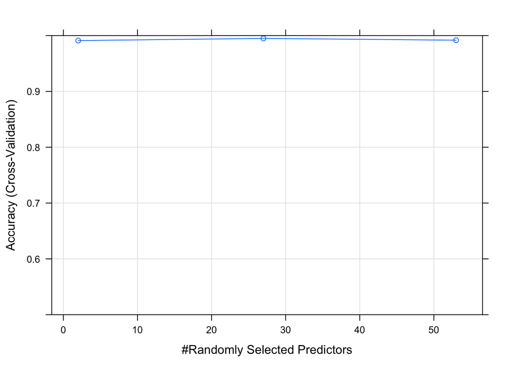

```r
plot(ModelFit1, ylim = c(0.5, 1))
```

## Model Two: Support Vector Machine

##### After complete the training process we also need to calculate out the accuracy. Later we will compare the accuracy of model two to that of the model one.

```r
#Use support vector machine model with cross validation
ModelFit2 <- train(classe ~ .,data = training,method = "svmRadial",trControl=trainControl(method="cv",number=4),verbose=F)
predictions2 <- predict(ModelFit2, testing)
Confusion_Matrix2 <- confusionMatrix(predictions2,testing$classe)
str(Confusion_Matrix2)#Displaying the internal structure of "Confusion_Matrix2"
```

```
## List of 5
##  $ positive: NULL
##  $ table   : 'table' int [1:5, 1:5] 2204 2 20 3 3 121 1356 38 3 0 ...
##   ..- attr(*, "dimnames")=List of 2
##   .. ..$ Prediction: chr [1:5] "A" "B" "C" "D" ...
##   .. ..$ Reference : chr [1:5] "A" "B" "C" "D" ...
##  $ overall : Named num [1:7] 0.928 0.908 0.922 0.933 0.284 ...
##   ..- attr(*, "names")= chr [1:7] "Accuracy" "Kappa" "AccuracyLower" "AccuracyUpper" ...
##  $ byClass : num [1:5, 1:8] 0.987 0.893 0.924 0.869 0.926 ...
##   ..- attr(*, "dimnames")=List of 2
##   .. ..$ : chr [1:5] "Class: A" "Class: B" "Class: C" "Class: D" ...
##   .. ..$ : chr [1:8] "Sensitivity" "Specificity" "Pos Pred Value" "Neg Pred Value" ...
##  $ dots    : list()
##  - attr(*, "class")= chr "confusionMatrix"
```

```r
overall <- Confusion_Matrix2$overall#The "Accuracy" is in the "overall" vector
overall.accuracy <- overall['Accuracy']#Get the "Accuracy"
AcM2 <- overall.accuracy
AcM2
```

```
##  Accuracy
## 0.9276064
```

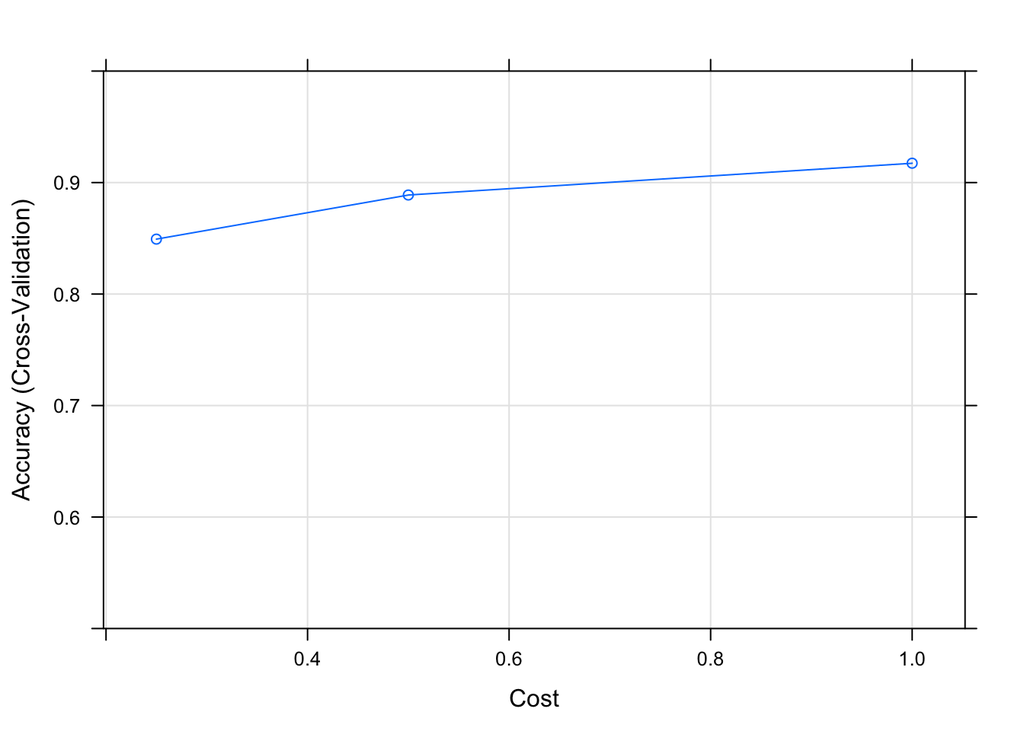

```r
plot(ModelFit2, ylim = c(0.5, 1))
```

## Select the Model with the Highest Accuracy

```r
Final_Model <- if (AcM1>AcM2) ModelFit1 else ModelFit2
R <- if (AcM1>AcM2) "Model One" else "Model Two"
#Get the most optimized model
R
```

```
## [1] "Model One"
```

```r
Final_Model$finalModel
```

```
##
## Call:
##  randomForest(x = x, y = y, mtry = param$mtry, verbose = ..1)
##                Type of random forest: classification
##                      Number of trees: 500
## No. of variables tried at each split: 27
##
##         OOB estimate of  error rate: 0.34%
## Confusion matrix:
##      A    B    C    D    E  class.error
## A 3347    1    0    0    0 0.0002986858
## B   12 2266    1    0    0 0.0057042563
## C    0    5 2048    1    0 0.0029211295
## D    0    0   12 1917    1 0.0067357513
## E    0    1    0    6 2158 0.0032332564
```

## Get Predictions for the Test Set and Write Them to Files

##### This is the final prediction based on the downloaded testing dataset.

```r
predict(Final_Model, TestingX)
```

```
##  [1] B A B A A E D B A A B C B A E E A B B B
## Levels: A B C D E
```

```r
prediction <- as.character(predict(Final_Model, TestingX))
pml_write_files = function(x){
  n = length(x)
  for(i in 1:n){
    filename = paste0("~/results/problem_id_", i, ".txt")
    write.table(x[i], file = filename, quote = FALSE, row.names = FALSE, col.names = FALSE)
  }
}
pml_write_files(prediction)
```